# Gustavo Diaz – mapor25

## Recovering Informative Estimates in Failed Placebo-Controlled List Experiments

**Gustavo Diaz**  
Northwestern University  
gustavo.diaz@northwestern.edu

**Verónica Pérez Bentancur**  
Universidad de la República veronica.perez@cienciassociales.edu.uy

**Ines Fynn**  
Universidad Católica del Uruguay ines.fynn@ucu.edu.uy

**Lucía Tiscornia**  
University College Dublin  
lucia.tiscornia@ucd.ie

Slides: gustavodiaz.org/talk

[figure not shown]

## List experiment

Now I am going to read you things that make people angry or upset

## List experiment

After I read them all, tell me HOW MANY of them upset you

## List experiment

I don’t want to know which ones, just tell me HOW MANY

### Control group

1. The federal government increasing tax on gasoline
2. Professional athletes getting million dollar contracts
3. Large corporations polluting the environment

## List experiment

I don’t want to know which ones, just tell me HOW MANY

### Treatment group

1. The federal government increasing tax on gasoline
2. Professional athletes getting million dollar contracts
3. Large corporations polluting the environment

## List experiment

I don’t want to know which ones, just tell me HOW MANY

### Treatment group

1. The federal government increasing tax on gasoline
2. Professional athletes getting million dollar contracts
3. Large corporations polluting the environment
4. **A black family moving next door**

## Reduces sensitivity bias

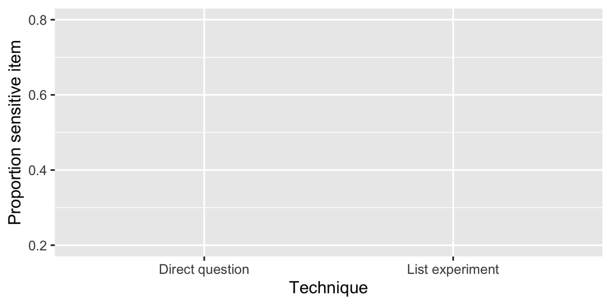

## Reduces sensitivity bias

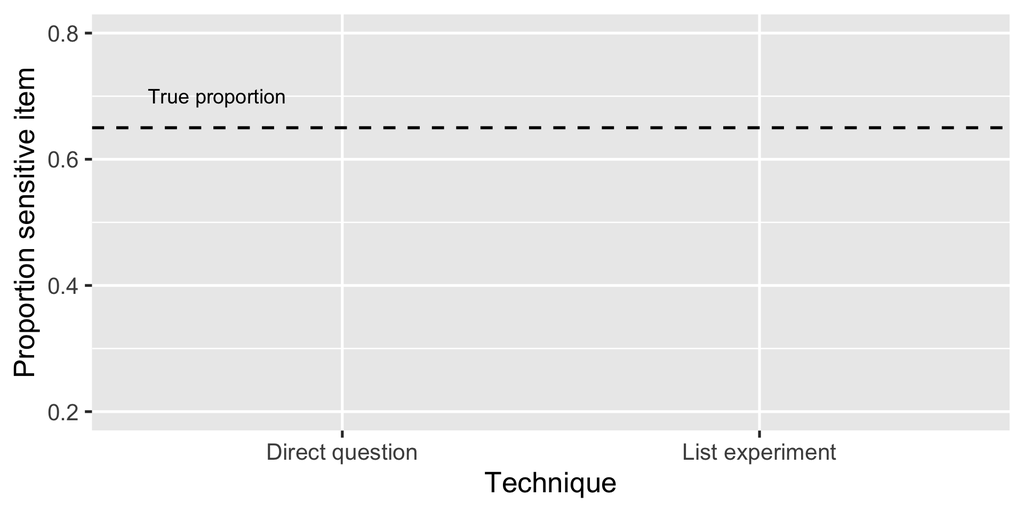

## Reduces sensitivity bias

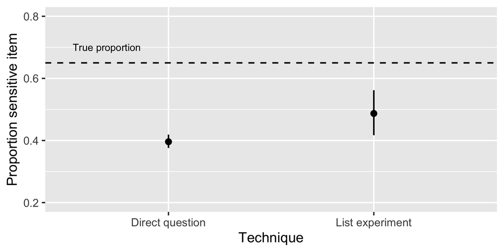

## Problem

Cannot see “true” proportion

How to tell if a list experiment brings you closer?

## Artificial inflation

| Control | Treatment |
| --- | --- |
| The federal government increasing tax on gasoline | The federal government increasing tax on gasoline |
| Professional athletes getting million dollar contracts | Professional athletes getting million dollar contracts |
| Large corporations polluting the environment | Large corporations polluting the environment |
|  | **A black family moving next door** |

Things that make people angry or upset

## Solution: Add a placebo statement

| Control | Treatment |
| --- | --- |
| The federal government increasing tax on gasoline | The federal government increasing tax on gasoline |
| Professional athletes getting million dollar contracts | Professional athletes getting million dollar contracts |
| Large corporations polluting the environment | Large corporations polluting the environment |
|  | **A black family moving next door** |

Things that make people angry or upset

## Solution: Add a placebo statement

| Control | Treatment |
| --- | --- |
| The federal government increasing tax on gasoline | The federal government increasing tax on gasoline |
| Professional athletes getting million dollar contracts | Professional athletes getting million dollar contracts |
| Large corporations polluting the environment | Large corporations polluting the environment |
| **Finding money in a jacket pocket** | **A black family moving next door** |

Things that make people angry or upset

## Placebo-controlled list experiments

Reduce bias from *non-strategic* response errors

But they can backfire if you pick a **bad placebo item**

## It happened to us!

## Our experiment

Things people have experienced in the last six months:

| List A | List B |
| --- | --- |
| Saw people doing sports | Saw people playing soccer |
| Visited friends | Chatted with friends |
| Activities by feminist groups | Activities by LGBTQ groups |
| Went to church | Went to charity events |

Online sample in Montevideo, Uruguay. $N = 2688$

## Manipulations

**Sensitive items:**

- Saw criminal groups threatening neighbors
- Saw criminal groups evicting neighbors from their homes
- Saw criminal groups making donations to neighbors
- Saw criminal groups offering work to neighbors

## Manipulations

**Sensitive items:**

- **Saw criminal groups threatening neighbors**
- Saw criminal groups evicting neighbors from their homes
- Saw criminal groups making donations to neighbors
- Saw criminal groups offering work to neighbors

**Placebo item:**

- I did not drink *mate*

## Our experiment

Things people have experienced in the last six months:

| List A | List B |
| --- | --- |
| Saw people doing sports | Saw people playing soccer |
| Visited friends | Chatted with friends |
| Activities by feminist groups | Activities by LGBTQ groups |
| Went to church | Went to charity events |

## Our experiment

Things people have experienced in the last six months:

| List A | List B |
| --- | --- |
| Saw people doing sports | Saw people playing soccer |
| Visited friends | Chatted with friends |
| Activities by feminist groups | Activities by LGBTQ groups |
| Went to church | Went to charity events |
| Saw criminal groups threatening neighbors | **I did not drink mate** |

## Our experiment

Things people have experienced in the last six months:

| List A | List B |
| --- | --- |
| Saw people doing sports | Saw people playing soccer |
| Visited friends | Chatted with friends |
| Activities by feminist groups | Activities by LGBTQ groups |
| Went to church | Went to charity events |
| **I did not drink mate** | Saw criminal groups threatening neighbors |

## Results

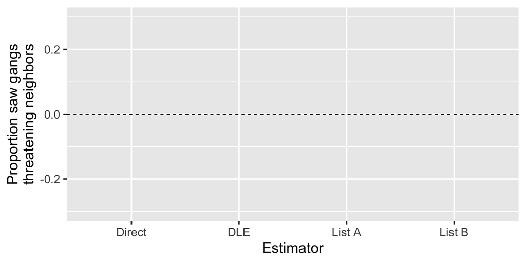

## Results

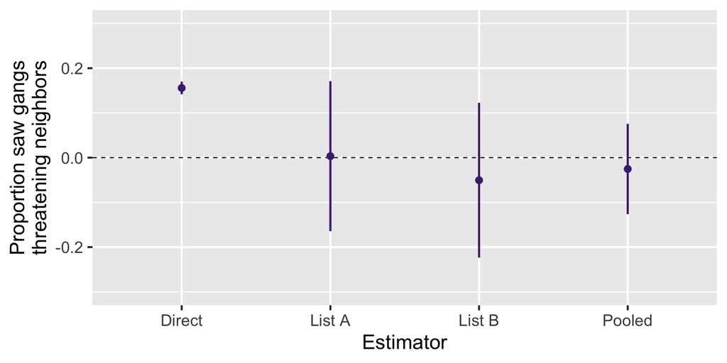

## What do we do?

Imagine how responses would have looked like without including the placebo

Equivalent to assuming estimated proportion is *partially identified*

Produce **non-parametric bounds**

## Sharp bounds

**Main idea:** Assume nothing beyond observed data and research design assumptions

**Experimental design:** Only control responses change

**Sharp bounds:** Impute minimun/maximum possible value

## Not very informative

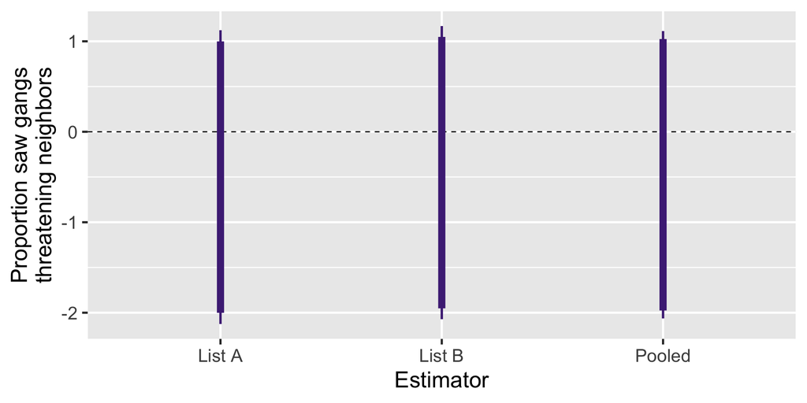

## What else can we assume?

**List experiment assumptions**

1. *No liars:* Rs do not endorse sensitive item when they it does not apply to them
2. *No design effects:* Adding/removing an item does not affect how R responds to other items

**Implications:**

1. Responses can only *decrease*
2. …by a magnitude of *one*

## List experiment bounds

**Implications:**

1. Responses can only *decrease*
2. …by a magnitude of *one*

**Lower bound:** All 5s become 4s

**Upper bound:** Everything decreases by one unless already 0

## A bit more informative?

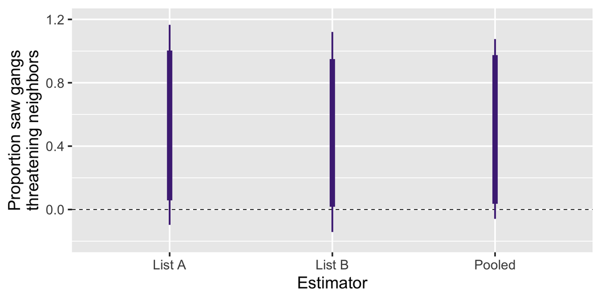

## Can we do better?

## Refinement

If you *know* the proportion of placebo holders in the population of interest

**Lower bound:** All 5s become 4s (unchanged)

**Upper bound:**
$$(1- \delta) \times \text{Observed proportion} + \delta \times \text{List upper bound}$$

where $\delta$ is the known placebo proportion

These bounds cannot be considered “sharp” anymore

## Imagine

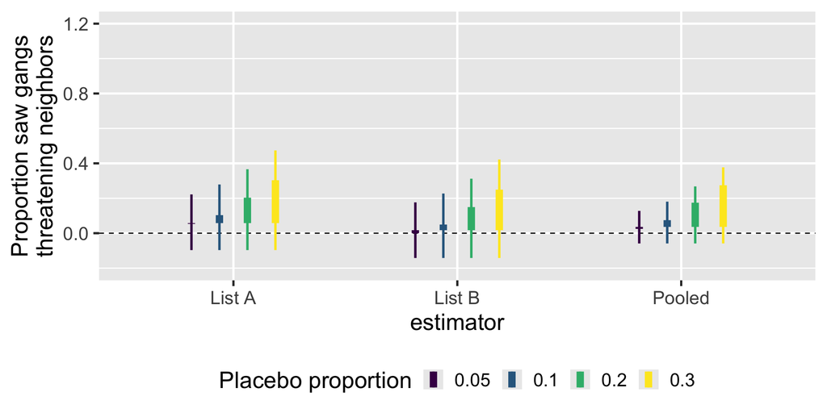

## Takeaways

- A **design-based** method to recover informative bounds in failed-placebo controlled experiment
- Also helpful to justify choice of placebo
- **Caveat:** This is a VERY EXTREME example
- Always ask about placebo items directly!

**Questions**

- Ideas to refine lower bounds?

[figure not shown]

**Slides:** gustavodiaz.org/talk